# R Notebook

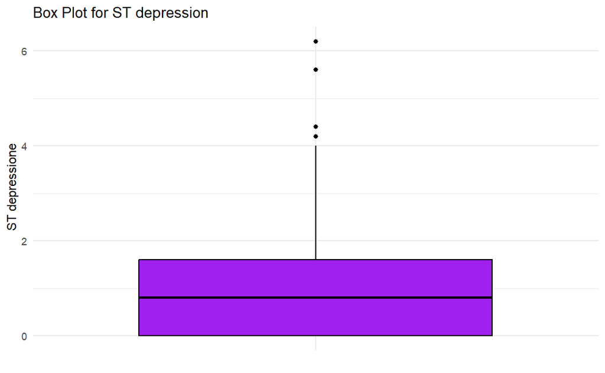

[figure not shown]

we can also detect summary of each attribute from the box plot , and we use box plot to detect the outlier.

Histogram

`r hist(dataset$chol)`

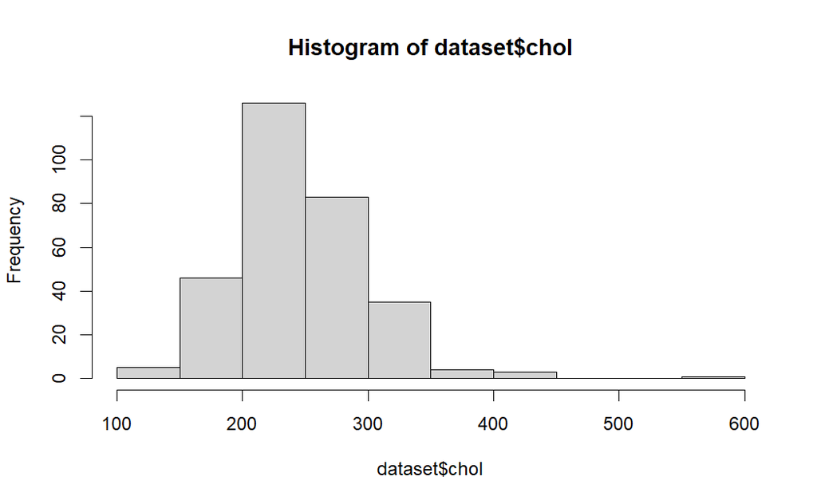

The graph represents the frequency of cholesterol in the data set. After observing the values, we concluded that most of the values fall in the range higher than the normal range, as the normal range falls between 125-200.

`r with(dataset, plot(age,chol, main = "Scatter Plot", xlab = "Age", ylab="chol"))`

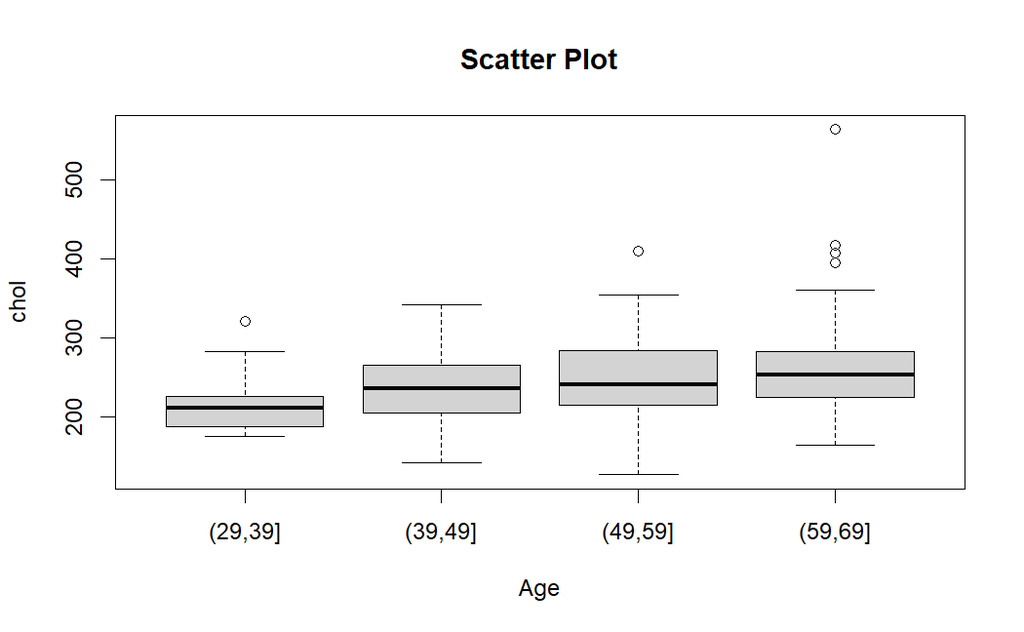

Bar plot There is no point in using bar plots because the frequency of one symptom (ex: high blood pressure alone ) is not enough to decide whether the patients are likely to have a heart-attack or not.

## outliers:

Detecting the outliers:

```r
boxplot.stats (dataset$age)$out
```

```
factor()
Levels: (29,39] (39,49] (49,59] (59,69]
```

```r
  boxplot.stats (dataset$chol)$out
```

```
[1] 417 564 394 407 409
```

```r
  boxplot.stats (dataset$trestbps)$out
```

```
[1] 172 178 180 180 200 174 192 178 180
```

```r
  boxplot.stats (dataset$oldpeak)$out
```

```
[1] 4.2 6.2 5.6 4.2 4.4
```

```r
  boxplot.stats (dataset$thalach)$out
```

```
[1] 71
```

Removing the outliers:

```r
outliers <- boxplot (dataset$chol, plot=FALSE) $out
 dataset <- dataset [-which(dataset$chol %in% outliers),]
 boxplot.stats (dataset$chol) $out
```

```
numeric(0)
```

The outlier in the attribute wasn’t a real Outlier and if we remove all the Outliers, our dataset affected and become small so we remove the Outlier from the attribute control that we noticed it is real Outlier.

[output not shown]

## feature selection

we did not applly feature selection beacause the number of attribute is small and we will neeed them.

[output not shown]

```r
print(data)
```

[output not shown]

[output cut: 128 more lines]

[output not shown]